# Risk and confidence maps for Vaccinium corymbosum

Amy J.S Davis

2023-06-24

### Create a global SDM for weighting pseudoabsences

#### Read in the global occurrence data for the target species that was downloaded using “global_download.Rmd”

```
[1] "Vaccinium corymbosum"
[1] "2882849"
```

#### Specify paths for output (defaults to file structure in ReadMe)

### Filter global occurrence data

```r
#remove unverified records
identificationVerificationStatus_to_discard <- c("unverified", "unvalidated","not able to validate","control could not be conclusive due to insufficient knowledge")

#enter value for max coordinate uncertainty in meters.

global.occ<-global %>%
  filter(speciesKey==taxonkey) %>%   #using taxonKey filters out accepted synonyms
  filter(is.na(coordinateUncertaintyInMeters)| coordinateUncertaintyInMeters< 1000) %>%
  filter(!str_to_lower(identificationVerificationStatus) %in% identificationVerificationStatus_to_discard)

global.occ$lon_dplaces<-sapply(global.occ$decimalLongitude, function(x) decimalplaces(x))
global.occ$lat_dplaces<-sapply(global.occ$decimalLatitude, function(x) decimalplaces(x))
global.occ[global.occ$lon_dplaces < 4& global.occ$lat_dplaces < 4 , ]<-NA
global.occ<-global.occ[ which(!is.na(global.occ$lon_dplaces)),]
global.occ<-within(global.occ,rm("lon_dplaces","lat_dplaces"))
global.occ<-global.occ[which( global.occ$year > 1975 & global.occ$year < 2020),]
```

#### Convert global occurrences to spatial points needed for modelling

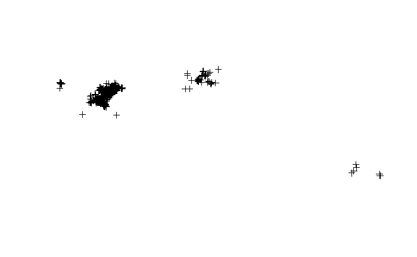

#### Flag and remove centroids and invalid georeferenced points

[output not shown]

#### Create global rasterstack using CHELSA data for model building

```r
globalclimrasters <- list.files((here("./data/external/climate/trias_CHELSA")),pattern='tif',full.names = T) #import CHELSA data
globalclimpreds <- stack(globalclimrasters)
```

#### Use SDMtab command from the SDMPlay package to remove duplicates per grid cell

```r
global.SDMtable<- SDMPlay:::SDMtab(global.occ.LL.cleaned, globalclimpreds, unique.data = TRUE,background.nb= 0) #
numb.pseudoabs <-length(global.SDMtable$id) #sets the number of pseudoabsences equal to number of unique presences


global.occ.sp<-global.SDMtable[c("longitude", "latitude")]
coordinates(global.occ.sp)<- c("longitude", "latitude")
global.occ.sp$species<- rep(1,length(global.occ.sp$latitude)) #adds columns indicating species presence needed for modeling
```

### Select wwf ecoregions that contain global occurrence points

### Specify and import bias grids for relevant taxonomic group (e.g vascular plants)

```r
biasgrid<-raster(here("./data/external/bias_grids/final/trias/plants_1deg_min5.tif"))### specify appropriate bias grid here
```

### Subset bias grid by ecoregions containing occurrence points

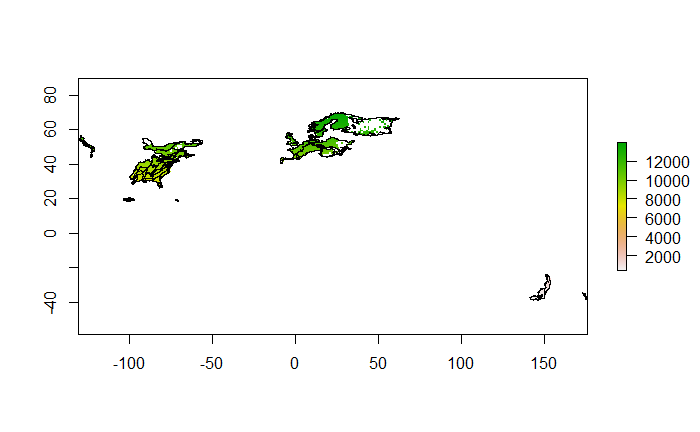

```r
ext_wwf_ecoSub<-extent(wwf_ecoSub1)
biasgrid_crop<-crop(biasgrid,ext_wwf_ecoSub)
biasgrid_sub<-mask(biasgrid_crop,wwf_ecoSub1)
 plot(biasgrid_sub)
 plot(wwf_ecoSub1,add=TRUE)
```

```r
NA
```

### Use randomPoints function from dismo package to locate pseduobasences within the bias grid subset

```r
set.seed(728)
global_points<-randomPoints(biasgrid_sub, numb.pseudoabs, global.occ.sp, ext=NULL, extf=1.1, excludep=TRUE, prob=FALSE, cellnumbers=FALSE, tryf=70, warn=2, lonlatCorrection=TRUE)
# will throw a warning if randomPoints generated is less than numb.pseudoabs. If this happens, increase the number of tryf or ignore bias grid and sample from ecoregion only.
```

### OPTIONAL: Sample from ecoregion only

```r
#  wwf_grid<-raster(here("./data/external/GIS/wwf_ecoregions_v1.tif"))
#  ecoregions_raster<-mask(wwf_grid,wwf_ecoSub1)
#  set.seed(768)
#  global_points<-randomPoints(ecoregions_raster, numb.pseudoabs, global.occ.sp, ext=NULL, extf=1.1, excludep=TRUE, prob=FALSE, cellnumbers=FALSE, tryf=150, warn=2, lonlatCorrection=TRUE)
```

### Extract generated pseudo absences and create presence-pseudobasence dataset

### Extract climate data for global scale modelling

```r
global.data <- sdmData(species~.,train=global_presabs, predictors=globalclimpreds)
global.data.df<-as.data.frame(global.data)
```

### Identify highly correlated predictors

| highlyCorrelated |
| --- |
| CHELSA_meantemp |
| CHELSA_minTmpColdestMon |
| CHELSA_precipWettestMon |
| CHELSA_annPrecip |
| CHELSA_temp_seasonality |

### Remove highly correlated predictors from dataframe

### Correct global clim preds values from integer format

### Use caretList from Caret package to run multiple machine learning models

```r
control <- trainControl(method="repeatedcv",number=10, repeats=10, savePredictions="final", preProc=c("center","scale"),classProbs=TRUE)
classList1 <- c("glm","gbm","rf","knn", "earth")
set.seed(457)
hideoutput<-capture.output(
global_train <- caretList(
  species~., data= global.data.df.uncor,
  trControl=control,
  methodList=classList1
))
```

```r
GlobalModelResults<-resamples(global_train)
summary(GlobalModelResults)# displays accuracy of each model
```

```
Call:
summary.resamples(object = GlobalModelResults)

Models: glm, gbm, rf, knn, earth
Number of resamples: 100

Accuracy
           Min.   1st Qu.    Median      Mean   3rd Qu.      Max. NA's
glm   0.6009852 0.6403941 0.6600985 0.6601555 0.6798030 0.7450980    0
gbm   0.7623762 0.8027118 0.8168317 0.8144422 0.8316832 0.8719212    0
rf    0.8078818 0.8323050 0.8465347 0.8471209 0.8627451 0.8970588    0
knn   0.7772277 0.8137255 0.8366337 0.8319377 0.8514851 0.8916256    0
earth 0.7029703 0.7496921 0.7728381 0.7720725 0.7948457 0.8423645    0

Kappa
           Min.   1st Qu.    Median      Mean   3rd Qu.      Max. NA's
glm   0.2022995 0.2806485 0.3199825 0.3203036 0.3597457 0.4901961    0
gbm   0.5247525 0.6053303 0.6336634 0.6288757 0.6633663 0.7438113    0
rf    0.6157356 0.6644820 0.6930693 0.6942432 0.7254902 0.7941176    0
knn   0.5544554 0.6274510 0.6732673 0.6638629 0.7029703 0.7832249    0
earth 0.4059406 0.4994847 0.5454726 0.5441390 0.5896913 0.6848132    0
```

```r
modelCor(resamples(global_train))# shows correlation among models.Weakly correlated algorithms are persuasive for stacking them in ensemble.
```

```
            glm       gbm        rf       knn     earth
glm   1.0000000 0.2949202 0.1911769 0.1942191 0.2081093
gbm   0.2949202 1.0000000 0.5516553 0.5781952 0.6029141
rf    0.1911769 0.5516553 1.0000000 0.5889041 0.3030091
knn   0.1942191 0.5781952 0.5889041 1.0000000 0.3025351
earth 0.2081093 0.6029141 0.3030091 0.3025351 1.0000000
```

### Create ensemble model (combine individual models into one)

```r
set.seed(478)
global_stack <- caretStack(
  global_train,
  method="glm",
  trControl=trainControl(method="cv",
                         number=10,
                         savePredictions= "final"  ))
print(global_stack)
```

```
A glm ensemble of 5 base models: glm, gbm, rf, knn, earth

Ensemble results:
Generalized Linear Model

20280 samples
    5 predictor
    2 classes: 'present', 'absent'

No pre-processing
Resampling: Cross-Validated (10 fold)
Summary of sample sizes: 18252, 18252, 18252, 18252, 18252, 18252, ...
Resampling results:

  Accuracy   Kappa
  0.8476824  0.6953649
```

### Create rasterstack of CHELSA climate data clipped to European modeling extent for prediction

```r
euclimrasters <- list.files((here("./data/external/climate/chelsa_eu_clips")),pattern='tif',full.names = T)
eu_climpreds<-stack(euclimrasters)
eu_climpreds.10<-divide10(eu_climpreds) # correct for integer format of Chelsa preds
```

### Restrict global model prediction to the extent of Europe

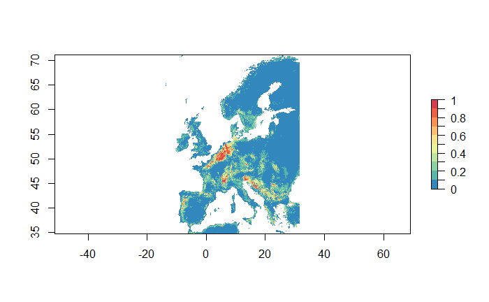

### Create European subset

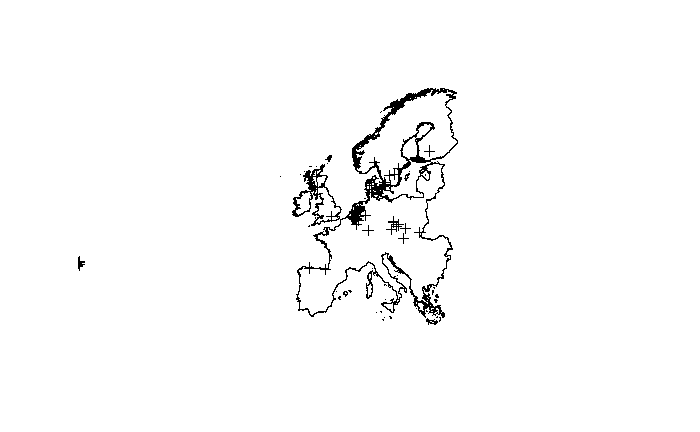

### Create RasterStack of European climate variables from RMI

#option 1. stack all available climate data (default)

```r
rmiclimrasters <- list.files((here("./data/external/climate/rmi_corrected")),pattern='tif',full.names = T)
rmiclimrasters #shows all available climate data
rmiclimpreds <- stack(rmiclimrasters) #includes all available climate data
```

#option 2. stack selected climate data

```r
# delete or comment any variables that should be excluded from the raster stack
climate.vars<-list("anngdd100.tif",
                         "annprecip_eea.tif",
                         "annpvarrecip_eea.tif",
                         "anntemp_eea.tif",
                         "dristprec.tif",
                         "maxtemp.tif",
                         "mintemp.tif",
                         "pet100.tif",
                         "SolRad100.tif",
                         "temprang.tif",
                         "tempseas.tif",
                         "varSolRad100.tif",
                          "wettprec.tif"

)

climate.vars.selected<-paste0(here("./data/external/climate/rmi_corrected"),"/", climate.vars)
rmiclimpreds<-stack(climate.vars)
```

### Use SDMtab command from the SDMPlay package to remove duplicates per 1km grid cell

```r
 # convert a single raster to LL for use in SDMtab
LLproj<-CRS("+proj=longlat +datum=WGS84 +no_defs +ellps=WGS84 +towgs84=0,0,0")
rmiclimpredLL<-projectRaster(rmiclimpreds$anntemp_eea, crs=LLproj)
rmiclimpredLL2<-projectRaster(rmiclimpreds$annprecip_eea, crs=LLproj)
rmipredstackLL<-stack(rmiclimpredLL,rmiclimpredLL2)

# Create SpatialPoints dataframe needed for SDMtab command.
euocc<-occ.eu@coords
 euocc1<-data.frame(euocc)[c(1:2)]
 names(euocc1)<-c("longitude", "latitude")


#run SDMtab command to remove duplicates
euocc.SDMtable<- SDMPlay:::SDMtab(euocc1, rmipredstackLL, unique.data = TRUE,same=TRUE)
numb.pseudoabs <- length(euocc.SDMtable$id)
```

### Transform eu occurrence dataset with unique presences back to a SpatialPoints dataframe.

```r
euocc<-euocc.SDMtable[c("longitude", "latitude")]
coordinates(euocc)<- c("longitude", "latitude")
euocc$occ<- rep(1,length(euocc$latitude))#adds columns indicating species presence needed for modeling
proj4string(euocc)<-CRS("+proj=longlat +datum=WGS84 +no_defs +ellps=WGS84 +towgs84=0,0,0")#specify here the existing projection of the data

rmiclipreds<-CRS("+proj=laea +lat_0=52 +lon_0=10 +x_0=4321000 +y_0=3210000 +ellps=GRS80 +towgs84=0,0,0,-0,-0,-0,0 +units=m +no_defs ")
rmiproj<-CRS("+proj=laea +lat_0=52 +lon_0=10 +x_0=4321000 +y_0=3210000 +ellps=GRS80 +towgs84=0,0,0,-0,-0,-0,0 +units=m +no_defs")
euocc1<-spTransform(euocc,rmiproj)
```

### Clip bias grid to European extent

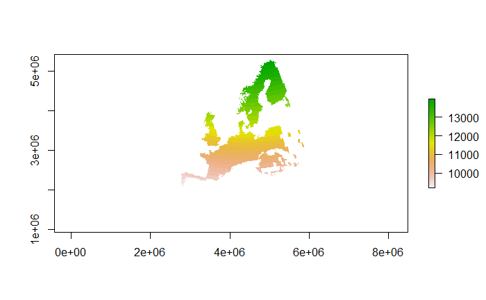

```r
studyextent<-euboundary
ecoregions_eu<-crop(biasgrid_sub,studyextent)
biasgrid_eu<-projectRaster(ecoregions_eu,rmiclimpreds)
plot(biasgrid_eu)
plot(studyextent,add=TRUE)
```

### Mask areas of high habitat suitability from global climate model

```r
#Read in global raster from earlier step if needed

#globalfilename<-paste(here("./data/processed/geotiffs/GlobalEnsEU_"), taxonkey, ".tif",sep="")
#global_model<-raster("C:/Users/Amy.Davis/OneDrive - Ipsos/Desktop/xps15/risk-modelling-and-mapping/data/processed/geotiffs/GlobalEnsEU_2882849.tif")


wgs84_gcs<-CRS("+proj=longlat +datum=WGS84 +no_defs +ellps=WGS84 +towgs84=0,0,0")
crs(global_model)<-wgs84_gcs
m<-global_model >.5
global_mask<-mask(global_model,m,maskvalue=TRUE)
global_masked_proj<-projectRaster(global_mask,biasgrid_eu)
```

### Overlay low predicted habitat suitability on bias grid to exclude low sampled areas

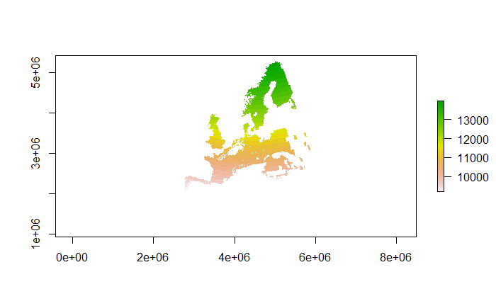

```r
pseudoSamplingArea<-mask(biasgrid_eu,global_masked_proj)
plot(pseudoSamplingArea)
```

### Randomly locate pseudo absences within “pseudoSamplingArea”

```r
set.seed=120
euocc_points<-randomPoints(pseudoSamplingArea, numb.pseudoabs, euocc, ext=NULL, extf=1.1, excludep=TRUE, prob=FALSE,cellnumbers=FALSE, tryf=50, warn=2, lonlatCorrection=TRUE)


euocc_pseudoAbs<-as.data.frame(euocc_points)
coordinates(euocc_pseudoAbs)<-c("x","y")
euocc_pseudoAbs$occ<-rep(0,length(euocc_pseudoAbs$x))

crs(euocc_pseudoAbs)<-CRS("+proj=laea +lat_0=52 +lon_0=10 +x_0=4321000 +y_0=3210000 +ellps=GRS80 +towgs84=0,0,0,-0,-0,-0,0 +units=m +no_defs ")
```

### Join eu occurrences with pseudo absences to create eu level presence-pseudoabsence dataset

```r
eu_presabs<- spRbind(euocc1,euocc_pseudoAbs)

crs(eu_presabs)<-CRS("+proj=laea +lat_0=52 +lon_0=10 +x_0=4321000 +y_0=3210000 +ellps=GRS80 +towgs84=0,0,0,-0,-0,-0,0 +units=m +no_defs ")
#confirm equal number of presences and absences
table(eu_presabs@data$occ)
```

```
  0   1
158 158
```

```r
#export occ points as shapefile
writeOGR(eu_presabs, dsn=(here("./data/processed/sdm_occ_pts/europe")), layer=paste(taxonName,"_EUpresabs",sep=""), driver="ESRI Shapefile", overwrite_layer = TRUE)
```

### Create SDM data object for European data

```
class                                 : sdmdata
===========================================================
number of species                     :  1
species names                         :  occ
number of features                    :  13
feature names                         :  anngdd100, annprecip_eea, annpvarrecip_eea, ...
type                                  :  Presence-Absence
has independet test data?             :  FALSE
number of records                     :  307
has Coordinates?                      :  TRUE
```

### Identify and remove highly correlated predictors from RMI rasterstack

```r
# convert eu data to dataframe
occeu.sdmdata.df<-as.data.frame(occeu.sdmdata)

#identify highly correlated predictors drop first two columns which always be rID and occ
correlationMatrix <- cor(occeu.sdmdata.df[,-c(1:2)])

# find attributes that are highly corrected
highlyCorrelated <- findCorrelation(correlationMatrix, cutoff=0.7,exact=TRUE,names=TRUE)
eupreds<-as.data.frame(highlyCorrelated)
kable(eupreds) %>%
kable_styling(bootstrap_options = c("striped"))
```

| highlyCorrelated |
| --- |
| mintemp |
| anntemp_eea |
| tempseas |
| anngdd100 |
| pet100 |
| annprecip_eea |
| dristprec |
| maxtemp |

```r
rmiclimpreds_uncor<-dropLayer(rmiclimpreds,highlyCorrelated)
```

### Add habitat and anthropogenic predictors

```
class                                 : sdmdata
===========================================================
number of species                     :  1
species names                         :  occ
number of features                    :  11
feature names                         :  annpvarrecip_eea, SolRad100, temprang, ...
type                                  :  Presence-Absence
has independet test data?             :  FALSE
number of records                     :  306
has Coordinates?                      :  TRUE
```

### Remove highly correlated predictors from the habitat/anthropogenic/climate stack (full stack)

```r
# first remove and identify low variance predictors
nzv_preds<-nearZeroVar(occeu.full.data.df,names=TRUE)
occeu.full.data.df1<-select (occeu.full.data.df,-c(nzv_preds))
# find attributes that are highly corrected
correlationMatrix <- cor(occeu.full.data.df1[,-1])
highlyCorrelated <- findCorrelation(correlationMatrix, cutoff=0.7,exact=TRUE,names=TRUE)
eupreds1<-as.data.frame(highlyCorrelated)
kable(eupreds1) %>%
kable_styling(bootstrap_options = c("striped"))
```

| highlyCorrelated |
| --- |

```r
# print names of highly correlated attributes
print(highlyCorrelated)
```

```
character(0)
```

```r
occeu.full.data.df1<-select (occeu.full.data.df1,-c(highlyCorrelated))
```

### Build models with climate and habitat data

```r
# uncomment 2nd control options for  LOOCV (leave one out cross validation, which is aka as "jacknife" ) which should be used when occurrences are smaller than n=10 for each predictor in the model)
occeu.full.data.df1$occ<-as.factor(occeu.full.data.df1$occ)
levels(occeu.full.data.df1$occ)<-c("absent","present")
#control<-trainControl(method="LOOCV",savePredictions="final", preProc=c("center","scale"),classProbs=TRUE)
control <- trainControl(method="repeatedcv",number=10, repeats=10,savePredictions="final",classProbs=TRUE)
mylist<-list(
  glm =caretModelSpec(method = "glm",maxit=100),
  gbm= caretModelSpec(method = "gbm"),
  rf = caretModelSpec(method = "rf", importance = TRUE),
  knn = caretModelSpec(method = "knn"),
  earth= caretModelSpec(method = "earth"))

set.seed(157)
hideout<-capture.output(model_train_habitat <- caretList(
  occ~., data=occeu.full.data.df1,
  trControl=control,
   tuneList=mylist))
```

### Display model evaluation statistics

```r
EU_ModelResults1<-resamples(model_train_habitat)
summary(EU_ModelResults1)
```

```
Call:
summary.resamples(object = EU_ModelResults1)

Models: glm, gbm, rf, knn, earth
Number of resamples: 100

Accuracy
           Min.   1st Qu.    Median      Mean   3rd Qu.      Max. NA's
glm   0.4666667 0.6333333 0.6774194 0.6729540 0.7419355 0.8333333    0
gbm   0.5161290 0.7274194 0.7741935 0.7587679 0.8064516 0.9000000    0
rf    0.5806452 0.7333333 0.8000000 0.7837887 0.8387097 0.9354839    0
knn   0.5161290 0.6747312 0.7096774 0.7178717 0.7741935 0.9333333    0
earth 0.6000000 0.7096774 0.7741935 0.7675673 0.8131720 0.9333333    0

Kappa
             Min.   1st Qu.    Median      Mean   3rd Qu.      Max. NA's
glm   -0.09090909 0.2666667 0.3487280 0.3438831 0.4817120 0.6636771    0
gbm    0.04123711 0.4555901 0.5469729 0.5185254 0.6141079 0.8000000    0
rf     0.16907216 0.4771167 0.5991071 0.5687026 0.6777547 0.8713693    0
knn    0.02922756 0.3448880 0.4199584 0.4336603 0.5455482 0.8660714    0
earth  0.20000000 0.4217598 0.5469729 0.5354820 0.6276961 0.8672566    0
```

```r
modelCor(resamples(model_train_habitat))
```

```
            glm       gbm        rf       knn     earth
glm   1.0000000 0.4914749 0.4339583 0.3561743 0.5193731
gbm   0.4914749 1.0000000 0.7249299 0.2459851 0.6890488
rf    0.4339583 0.7249299 1.0000000 0.2093460 0.6981864
knn   0.3561743 0.2459851 0.2093460 1.0000000 0.2788552
earth 0.5193731 0.6890488 0.6981864 0.2788552 1.0000000
```

### Create ensemble model

```r
set.seed(458)
control <- trainControl(method="cv",number=10, savePredictions="final",classProbs=TRUE)
model_train_habitat1 <- caretList(
  occ~., data=occeu.full.data.df1,
  trControl=control,
   tuneList=mylist)

EU_Ens_ModelResults1<-resamples(model_train_habitat1)
summary(EU_Ens_ModelResults1)
modelCor(resamples(model_train_habitat1))

set.seed(456)
hideoutput<-capture.output(
lm_ens_hab<-caretEnsemble(model_train_habitat1, trControl=trainControl(method="cv",                                                                number=10,savePredictions= "final",classProbs = TRUE)))

lm_ens_hab
```

```r
variableImportance<-varImp(lm_ens_hab)
kable(variableImportance,digits=2,caption="Variable Importance") %>%
kable_styling(bootstrap_options = c("striped"))
```

Variable Importance

|  | overall | glm | gbm | rf | knn | earth |
| --- | --- | --- | --- | --- | --- | --- |
| corine_perConiferous | 1.78 | 6.81 | 0.00 | 0.00 | 4.05 | 0.00 |
| corine_perWetland | 1.80 | 5.51 | 0.57 | 1.85 | 0.81 | 0.00 |
| corine_perdeciduous | 2.93 | 14.24 | 1.83 | 1.39 | 0.00 | 0.00 |
| wettprec | 7.87 | 13.22 | 13.64 | 9.67 | 2.95 | 0.00 |
| corine_perAgriculture | 8.16 | 12.78 | 5.58 | 5.38 | 3.64 | 17.91 |
| ESM1000m_singleINT_ext | 8.31 | 0.00 | 6.93 | 9.06 | 21.36 | 0.00 |
| varSolRad100 | 13.13 | 6.56 | 5.35 | 10.98 | 16.98 | 25.66 |
| annpvarrecip_eea | 13.68 | 6.22 | 20.32 | 14.82 | 25.37 | 0.00 |
| temprang | 14.08 | 18.81 | 17.24 | 13.12 | 22.54 | 0.00 |
| SolRad100 | 28.26 | 15.84 | 28.55 | 33.74 | 2.32 | 56.43 |

```r
write.csv(variableImportance,file = paste0(genOutput,taxonkey,"_varImp.csv"))
```

### Use EU level ensemble model (ensModel) to predict for Europe

```r
 ens_pred_hab_eu<-raster::predict(fullstack,lm_ens_hab,type="prob")
 ens_pred_hab_eu1<-1-ens_pred_hab_eu

 writeRaster(ens_pred_hab_eu1,filename=file.path(rasterOutput,paste("eu_",taxonkey, "_hist.tif",sep="")) , format="GTiff",overwrite=TRUE)

exportPNG(ens_pred_hab_eu1,taxonkey,taxonName=taxonName,"hist.png")
```

```r
  brks <- seq(0, 1, by=0.1)
  nb <- length(brks)-1
  pal <- colorRampPalette(rev(brewer.pal(8, 'Spectral')))
   cols<-pal(nb)
  plot(ens_pred_hab_eu1, breaks=brks, col=cols,lab.breaks=brks)
   plot(euocc1,pch=1,cex=0.50,add=TRUE)#plots species presences
```

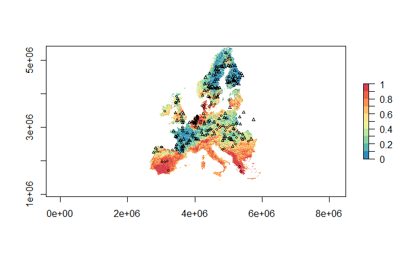

```r
    plot(euocc_pseudoAbs,pch=2,cex=0.50,add=TRUE)#plots species pseudoabsences
```

```r
NA
NA
```

### Predict for Belgium only using EU-level ensemble model to forecast risk under historical climate conditions

```r
laea_grs80<-CRS("+proj=laea +lat_0=52 +lon_0=10 +x_0=4321000 +y_0=3210000 +ellps=GRS80 +towgs84=0,0,0,-0,-0,-0,0 +units=m +no_defs ")
ens_pred_hab<-raster::predict(fullstack_be,lm_ens_hab,type="prob")
ens_pred_hab1<-1-ens_pred_hab
crs(ens_pred_hab1)<-laea_grs80
writeRaster(ens_pred_hab1, filename=file.path(rasterOutput,paste("be_",taxonkey, "_hist.tif",sep="")),  format="GTiff",overwrite=TRUE)
exportPDF(ens_pred_hab1,taxonkey,taxonName=taxonName,"eu_hist.pdf")
exportPNG(ens_pred_hab1,taxonkey,taxonName=taxonName,"eu_hist.png")
```

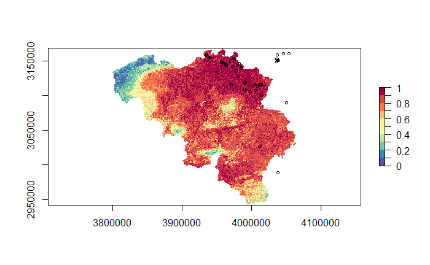

```r
brks <- seq(0, 1, by=0.1)
  nb <- length(brks)-1
  pal <- colorRampPalette(rev(brewer.pal(11, 'Spectral')))
  cols<-pal(nb)
  plot(ens_pred_hab1, breaks=brks, col=cols,lab.breaks=brks)
  plot(euocc1,pch=1,cex=0.75,add=TRUE)
```

```r
  #plot(euocc_pseudoAbs,pch=2,cex=0.75,add=TRUE)
```

### Clip habitat stack to Belgium

#### use this stack for vertebrates or anything likely to be influenced by water availability

```r
# habitat_stack<-stack(habitat,dist2water)
# habitat_only_stack<-crop(habitat_stack,country)
# habitat_only_stack_be<-crop(habitat_only_stack,country)
```

## use this stack for plants

```r
habitat_stack<-stack(habitat)
habitat_only_stack<-crop(habitat_stack,country)
habitat_only_stack_be<-crop(habitat_only_stack,country)
```

### Create individual RCP (2.6, 4.5, 8.5) climate data stacks for Belgium

```r
be26 <- list.files((here("./data/external/climate/byEEA_finalRCP/belgium_rcps/rcp26")),pattern='tif',full.names = T)
belgium_stack26 <- stack(be26)

be45 <- list.files((here("./data/external/climate/byEEA_finalRCP/belgium_rcps/rcp45")),pattern='tif',full.names = T)
belgium_stack45 <- stack(be45)

be85 <- list.files((here("./data/external/climate/byEEA_finalRCP/belgium_rcps/rcp85")),pattern='tif',full.names = T)
belgium_stack85 <- stack(be85)
```

### Combine habitat stacks with climate stacks for each RCP scenario

```r
fullstack26<-stack(be26,habitat_only_stack_be)
fullstack45<-stack(be45,habitat_only_stack_be)
fullstack85<-stack(be85,habitat_only_stack_be)
```

### Create and export RCP risk maps for each RCP scenario

```r
ens_pred_hab26<-raster::predict(fullstack26,lm_ens_hab,type="prob")
ens_pred_hab26_1<-1-ens_pred_hab26
crs(ens_pred_hab26_1)<-laea_grs80
writeRaster(ens_pred_hab26_1, filename=file.path(rasterOutput,paste("be_",taxonkey, "_rcp26.tif",sep="")), format="GTiff",overwrite=TRUE)
exportPDF(ens_pred_hab26_1,taxonkey,taxonName=taxonName,"rcp26.pdf")
```

```r
ens_pred_hab45<-raster::predict(fullstack45,lm_ens_hab,type="prob")
ens_pred_hab45_1<-1-ens_pred_hab45
crs(ens_pred_hab45_1)<-laea_grs80
writeRaster(ens_pred_hab45_1, filename=file.path(rasterOutput,paste("be_",taxonkey, "_rcp45.tif",sep="")), format="GTiff",overwrite=TRUE)
exportPDF(ens_pred_hab45_1,taxonkey,taxonName=taxonName,"rcp45.pdf")
```

```r
ens_pred_hab85<-raster::predict(fullstack85,lm_ens_hab,type="prob")
ens_pred_hab85_1<-1-ens_pred_hab85
crs(ens_pred_hab85_1)<-laea_grs80
writeRaster(ens_pred_hab85_1, filename=file.path(rasterOutput,paste("be_",taxonkey, "_rcp85.tif",sep="")), format="GTiff",overwrite=TRUE)
exportPDF(ens_pred_hab85_1,taxonkey,taxonName=taxonName,"rcp85.pdf")
```

### Display RCP risk maps

```r
plot(ens_pred_hab26_1,breaks=brks, col=cols,lab.breaks=brks)
plot(ens_pred_hab45_1,breaks=brks, col=cols,lab.breaks=brks)
plot(ens_pred_hab85_1,breaks=brks, col=cols,lab.breaks=brks)
```

[output not shown]

### Create and export “difference maps”: the difference between predicted risk by each RCP scenario and historical climate

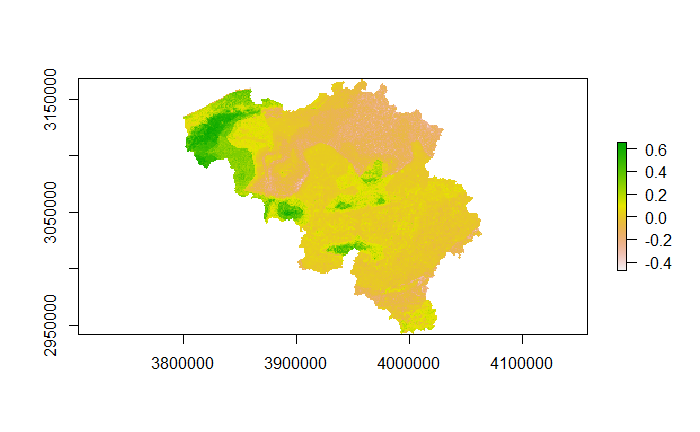

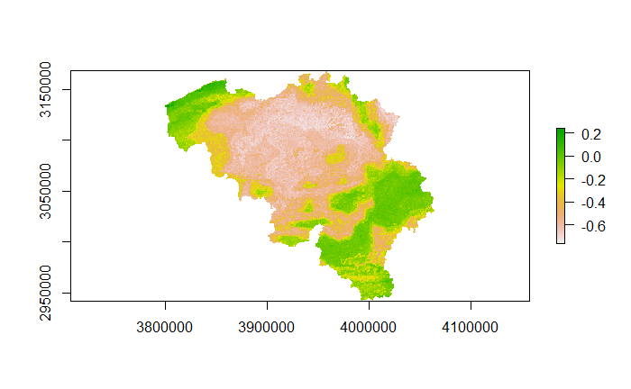

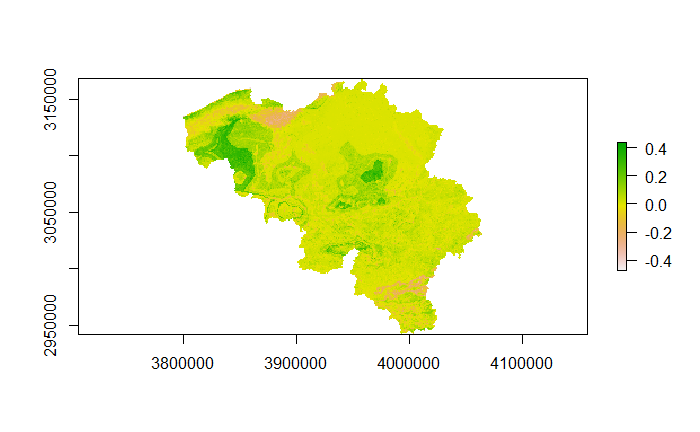

### Output predictor data used for SDM

```r
df4export<-cbind(occeu.full.data.df1,coordinates(occ.full.data))
write.csv(df4export, paste(genOutput,taxonkey,"_sdmdata.csv",sep=""))
```

### Check spatial autocorrelation of residuals to assess whether occurrence data should be thinned

#### derive residuals from unthinned model

```r
predEns1<-lm_ens_hab$ens_model$pred
obs.numeric<-ifelse(predEns1$obs == "absent",0,1)
```

#### standardize residuals

```r
stdres<-function(obs.numeric, yhat){
  num<-obs.numeric-yhat
  denom<-sqrt(yhat*(1-yhat))
  return(num/denom)
}
hab.res<-stdres(obs.numeric,predEns1$present)


res.best.coords<-cbind(coordinates(occ.full.data),hab.res)
res.best.geo<-as.geodata(res.best.coords,coords.col=1:2,data.col = 3)
summary(res.best.geo) #note distance is in meters
```

```
Number of data points: 306

Coordinates summary
    longitude latitude
min   2778500  1671780
max   5676500  5220500

Distance summary
         min          max
    966.5814 3901712.7747

Data summary
       Min.     1st Qu.      Median        Mean     3rd Qu.        Max.
-3.19190719 -0.50038446  0.20438498  0.04452631  0.36710510  4.46397809
```

### Check Morans I.

```r
#If Moran's I is very low (<0.10), or not significant, do not need to thin occurrences.
library(ape)
res.best.df<-as.data.frame(res.best.coords)
occ.dists <- as.matrix(dist(cbind(res.best.df[1], res.best.df[2])))
occ.dists.inv <- 1/occ.dists
diag(occ.dists.inv) <- 0
Moran.I(res.best.df$hab.res,occ.dists.inv,scaled=TRUE,alternative="greater")
```

```
$observed
[1] 0.00664346

$expected
[1] -0.003278689

$sd
[1] 0.01297856

$p.value
[1] 0.2222838
```

### Code for conformal prediction functions

### Quantify confidence of predicted values using class conformal prediction

```r
# confidence map for Belgium for predicted risk under historical climate
pvalsdf_hist<-classConformalPrediction(lm_ens_hab,ens_pred_hab)
# Confidence maps for Belgium under RCP scenarios of climate change
pvalsdf_rcp26<-classConformalPrediction(lm_ens_hab,ens_pred_hab26)
pvalsdf_rcp45<-classConformalPrediction(lm_ens_hab,ens_pred_hab45)
pvalsdf_rcp85<-classConformalPrediction(lm_ens_hab,ens_pred_hab85)

# option to export confidence and pvals as csv
write.csv(pvalsdf_hist,file=paste(genOutput,"confidence_",taxonkey, "_hist.csv",sep=""))
```

### Create confidence maps

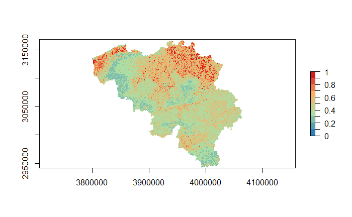

```r
brks <- seq(0, 1, by=0.1)
  nb <- length(brks)-1
  pal <- colorRampPalette(rev(brewer.pal(4, 'Spectral')))
  cols<-pal(nb)


confidenceMaps<-function(x,taxonkey,taxonName,maptype){
pvals_dataframe<-get("x")
data.xyz <- pvals_dataframe[c("x","y","conf")]
rst <- rasterFromXYZ(data.xyz)
crs(rst)<-CRS("+proj=laea +lat_0=52 +lon_0=10 +x_0=4321000 +y_0=3210000 +ellps=GRS80 +units=m +no_defs")
plot(rst,breaks=brks, col=cols,lab.breaks=brks)
writeRaster(rst, filename=file.path(rasterOutput,paste("be_",taxonkey, "_",maptype,".tif",sep="")), format="GTiff",overwrite=TRUE)
exportPDF(rst,taxonkey,taxonName=taxonName,nameextension= paste(maptype,".pdf",sep=""))
}

hist.conf.map<-confidenceMaps(pvalsdf_hist,taxonkey,taxonName,maptype="hist_conf")
```

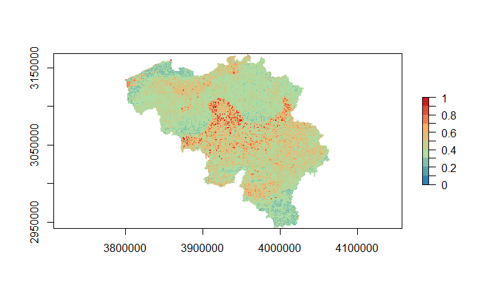

```r
rcp26.conf.map<-confidenceMaps(pvalsdf_rcp26,taxonkey,taxonName,maptype="rcp26_conf")
```

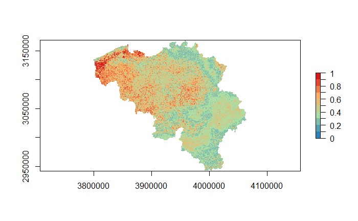

```r
rcp45.conf.map<-confidenceMaps(pvalsdf_rcp45,taxonkey,taxonName,maptype="rcp45_conf")
```

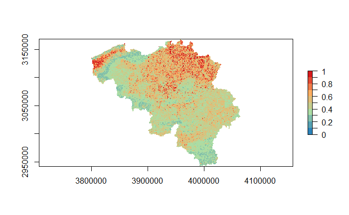

```r
rcp85.conf.map<-confidenceMaps(pvalsdf_rcp85,taxonkey,taxonName,maptype="rcp85_conf")
```

### Mask areas of below a set confidence level

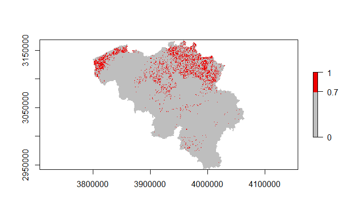

```r
# Cutoff for "high" confidence can be modified below. cutoff should be a value betwee 0 and 1
cutoff<-0.7

brks <- c(0,cutoff,1.0)
  nb <- length(brks)
  cols<-c("gray","red2")

hist.conf.thresh.map<-confidenceMaps(pvalsdf_hist,taxonkey,taxonName,maptype="hist_conf_thresh")
```

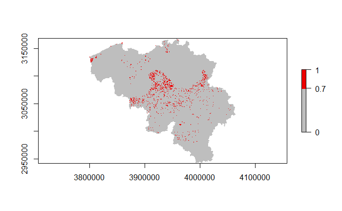

```r
rcp26.conf.thresh.map<-confidenceMaps(pvalsdf_rcp26,taxonkey,taxonName,maptype="rcp26_conf_thresh")
```

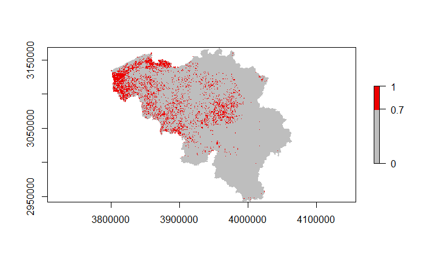

```r
rcp45.conf.thresh.map<-confidenceMaps(pvalsdf_rcp45,taxonkey,taxonName,maptype="rcp45_conf_thresh")
```

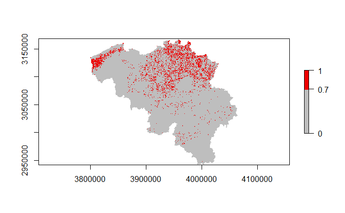

```r
rcp85.conf.thresh.map<-confidenceMaps(pvalsdf_rcp85,taxonkey,taxonName,maptype="rcp85_conf_thresh")
```

### Model evalution summary

```r
meanResults<-summary(EU_Ens_ModelResults1)
eu_accuracy<-meanResults$statistics$Accuracy
eu_kappa<-meanResults$statistics$Kappa

write.csv(eu_accuracy,file=paste0(genOutput,taxonkey,"_accuracy.csv"))
write.csv(eu_kappa,file=paste0(genOutput,taxonkey,"_kappa.csv"))

# derive sensitivity and specificity
 table(predEns1$pred,predEns1$obs)
```

```
          absent present
  absent     117      40
  present     31     118
```

```r
 sensitivity(predEns1$pred,predEns1$obs)
```

```
[1] 0.7905405
```

```r
 specificity(predEns1$pred,predEns1$obs)
```

```
[1] 0.7468354
```

```r
 sens<-sensitivity(predEns1$pred,predEns1$obs)
 spec<-specificity(predEns1$pred,predEns1$obs)

moransI<-Moran.I(res.best.df$hab.res,occ.dists.inv,scaled=TRUE,alternative="greater")
MoransI<-moransI$observed
ensembleEvaluation<-(lm_ens_hab$ens_model$results[2:5])

modelEvaluation<-cbind(sens,spec,MoransI,ensembleEvaluation)
write.csv(modelEvaluation,file=paste0(genOutput,taxonkey,"_ModelEval.csv"))
```

### Generate and export response curves in order of variable importance

```r
topPreds <- variableImportance[with(variableImportance,order(-overall)),]
varNames<-rownames(topPreds)
# combine predictions from each model for each variable
partial_gbm<-function(x){
  m.gbm<-pdp::partial(model_train_habitat$gbm$finalModel,pred.var=paste(x),train = occeu.full.data.df1,type="classification",
                      prob=TRUE,n.trees= model_train_habitat$gbm$finalModel$n.trees, which.class = 2,grid.resolution=nrow(occeu.full.data.df1))
}



gbm.partial.list<-lapply(varNames,partial_gbm)

partial_glm<-function(x){
m.glm<-pdp::partial(model_train_habitat$glm$finalModel,pred.var=paste(x),train = occeu.full.data.df1,type="classification",
              prob=TRUE,which.class = 2,grid.resolution=nrow(occeu.full.data.df1))
}

glm.partial.list<-lapply(varNames,partial_glm)

partial_rf<-function(x){
  pdp::partial(model_train_habitat$rf$finalModel,pred.var=paste(x),train = occeu.full.data.df1,type="classification",
              prob=TRUE,which.class = 2,grid.resolution=nrow(occeu.full.data.df1))
}

rf.partial.list<-lapply(varNames,partial_rf)

partial_knn<-function(x){
m.knn<-pdp::partial(model_train_habitat$knn,pred.var=paste(x),train = occeu.full.data.df1,type="classification",
               prob=TRUE,which.class = 2,grid.resolution=nrow(occeu.full.data.df1))
}

knn.partial.list<-lapply(varNames,partial_knn)




partial_mars<-function(x){
m.mars<-pdp::partial(model_train_habitat$earth$finalModel,pred.var=paste(x),train = occeu.full.data.df1,type="classification",
              prob=TRUE,which.class = 2,grid.resolution=nrow(occeu.full.data.df1))
}

mars.partial.list<-lapply(varNames,partial_mars)


names(glm.partial.list)<-varNames
names(gbm.partial.list)<-varNames
names(rf.partial.list)<-varNames
names(knn.partial.list)<-varNames
names(mars.partial.list)<-varNames

glm.partial.df<-as.data.frame(glm.partial.list)
gbm.partial.df<-as.data.frame(gbm.partial.list)
rf.partial.df<-as.data.frame(rf.partial.list)
knn.partial.df<-as.data.frame(knn.partial.list)

mars.partial.df<-as.data.frame(mars.partial.list)

predx<-data.frame()
predy<-data.frame()

for (i in varNames){
  predx <- rbind(predx, as.data.frame(paste(i,i,sep=".")))
  predy<- rbind(predy,as.data.frame(paste(i,"yhat",sep=".")))
}
names(predx)<-""
names(predy)<-""

predx1<-t(predx)
predy1<-t(predy)


glm.partial.df$data<-'GLM'
gbm.partial.df$data<-'GBM'
rf.partial.df$data<-'RF'
knn.partial.df$data<-'KNN'
mars.partial.df$data<-'MARS'

all_dfs<-rbind.data.frame(glm.partial.df,gbm.partial.df,rf.partial.df,knn.partial.df,mars.partial.df)


responseCurves<-function(x,y) {
  colors <- c("GLM" = "gray", "GBM"="red","RF"="blueviolet","KNN"="chartreuse", "MARS"= "hotpink")
  ggplot(all_dfs,(aes(x=.data[[x]],y=.data[[y]]))) +
    geom_line(aes(color = data), size =1.2, position=position_dodge(width=0.2))+
   theme_bw()+
    labs(y="Partial probability", x= gsub("//..*","",x),color="Legend") +
    scale_color_manual(values = colors)
}

allplots<-map2(predx1,predy1, ~responseCurves(.x,.y))
#export plots as PNGs
for(i in seq_along(allplots)){
  png(paste0(genOutput,taxonkey,"_",i,".png"),width = 5, height = 5, units = "in",res=300)
  print(allplots[[i]])
  dev.off()
}
```

### Plot response curves

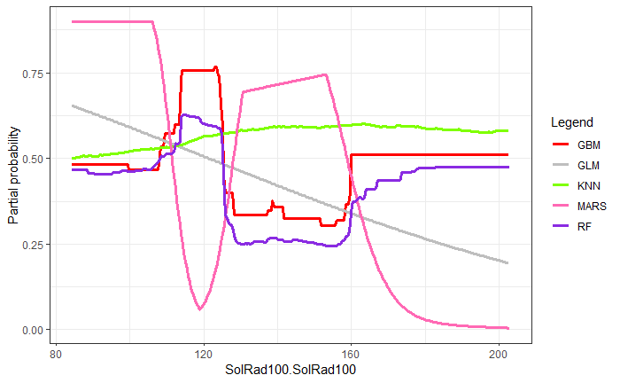

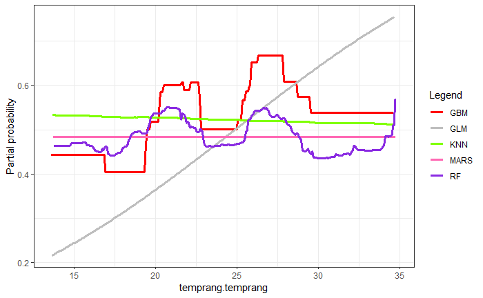

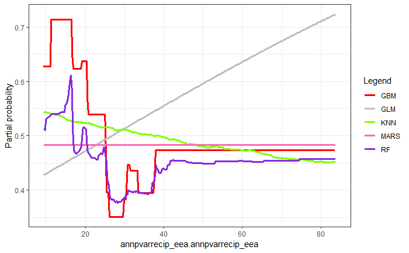

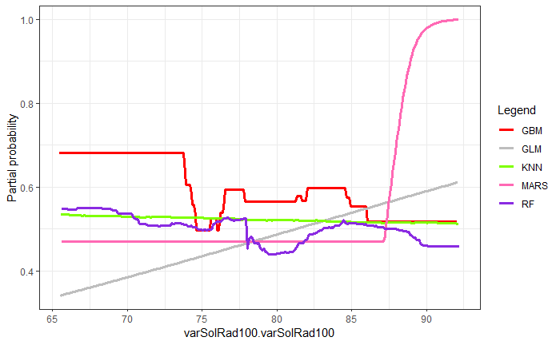

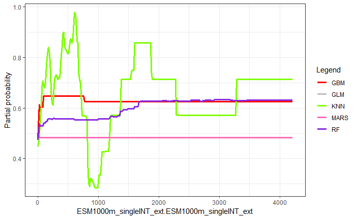

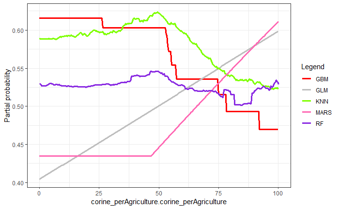

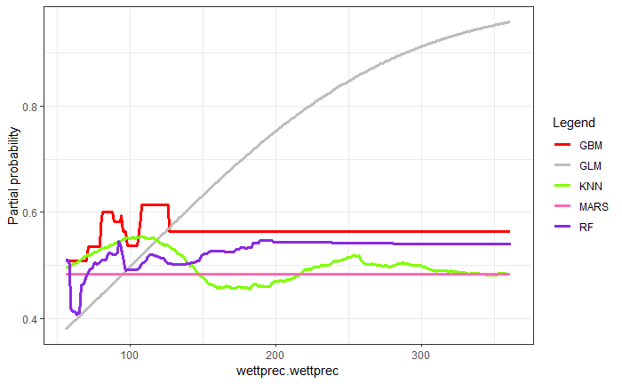

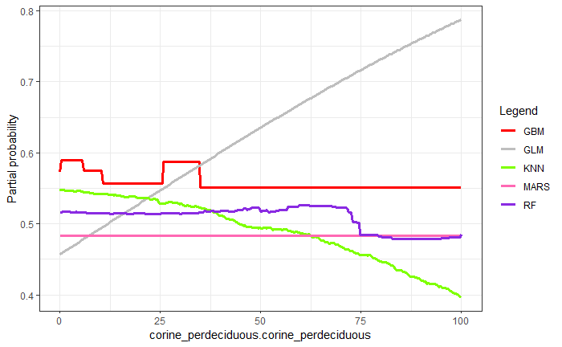

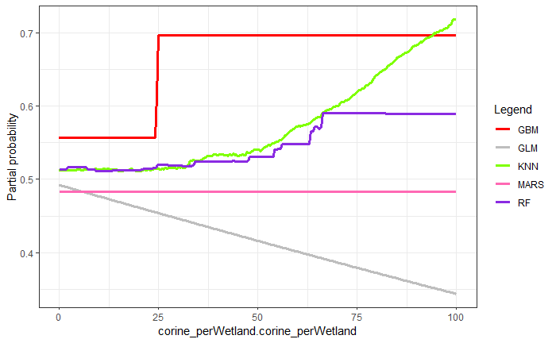

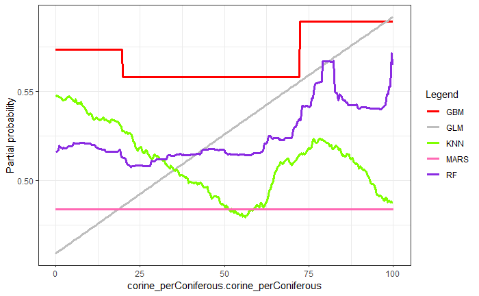

```r
par(mfrow=c(3,3))
for(i in seq_along(allplots)){
  print(allplots[[i]])
}
```